# Lab 06 - Text Mining

# Learning goals

- Use `unnest_tokens()` and `unnest_ngrams()` to extract tokens and ngrams from text.
- Use dplyr and ggplot2 to analyze text data

# Lab description

For this lab we will be working with a new dataset. The dataset contains transcription samples from https://www.mtsamples.com/. And is loaded and “fairly” cleaned at https://raw.githubusercontent.com/USCbiostats/data-science-data/master/00_mtsamples/mtsamples.csv.

This markdown document should be rendered using `github_document` document.

# Setup the Git project and the GitHub repository

1. Go to your documents (or wherever you are planning to store the data) in your computer, and create a folder for this project, for example, “PM566-labs”
2. In that folder, save [this template](https://raw.githubusercontent.com/USCbiostats/PM566/master/content/assignment/06-lab.Rmd) as “README.Rmd”. This will be the markdown file where all the magic will happen.
3. Go to your GitHub account and create a new repository, hopefully of the same name that this folder has, i.e., “PM566-labs”.
4. Initialize the Git project, add the “README.Rmd” file, and make your first commit.
5. Add the repo you just created on GitHub.com to the list of remotes, and push your commit to origin while setting the upstream.

### Setup packages

You should load in `dplyr`, (or `data.table` if you want to work that way), `ggplot2` and `tidytext`. If you don’t already have `tidytext` then you can install with

```r
install.packages("tidytext")
```

### read in Medical Transcriptions

Loading in reference transcription samples from https://www.mtsamples.com/

```r
library(readr)
library(ggplot2)
library(tidytext)
library(dplyr)

mt_samples <- read_csv("/Users/sherryshen/Desktop/mtsamples.txt")
mt_samples <- mt_samples %>%
  select(description, medical_specialty, transcription)

head(mt_samples)
```

```
## # A tibble: 6 x 3
##   description                  medical_specialty   transcription
##   <chr>                        <chr>               <chr>
## 1 A 23-year-old white female … Allergy / Immunolo… "SUBJECTIVE:,  This 23-year-…
## 2 Consult for laparoscopic ga… Bariatrics          "PAST MEDICAL HISTORY:, He h…
## 3 Consult for laparoscopic ga… Bariatrics          "HISTORY OF PRESENT ILLNESS:…
## 4 2-D M-Mode. Doppler.         Cardiovascular / P… "2-D M-MODE: , ,1.  Left atr…
## 5 2-D Echocardiogram           Cardiovascular / P… "1.  The left ventricular ca…
## 6 Morbid obesity.  Laparoscop… Bariatrics          "PREOPERATIVE DIAGNOSIS: , M…
```

```r
#mt_samples$transcription[1]
```

## Question 1: What specialties do we have?

We can use `count()` from `dplyr` to figure out how many different categories do we have? Are these categories related? overlapping? evenly distributed?

```r
mt_samples %>%
  count(medical_specialty, sort = TRUE)
```

```
## # A tibble: 40 x 2
##    medical_specialty                 n
##    <chr>                         <int>
##  1 Surgery                        1103
##  2 Consult - History and Phy.      516
##  3 Cardiovascular / Pulmonary      372
##  4 Orthopedic                      355
##  5 Radiology                       273
##  6 General Medicine                259
##  7 Gastroenterology                230
##  8 Neurology                       223
##  9 SOAP / Chart / Progress Notes   166
## 10 Obstetrics / Gynecology         160
## # … with 30 more rows
```

We can see that among medical_specialty, “Surgery” is the most frequent one with n=1103.

## Question 2

- Tokenize the the words in the `transcription` column
- Count the number of times each token appears
- Visualize the top 20 most frequent words

Explain what we see from this result. Does it makes sense? What insights (if any) do we get?

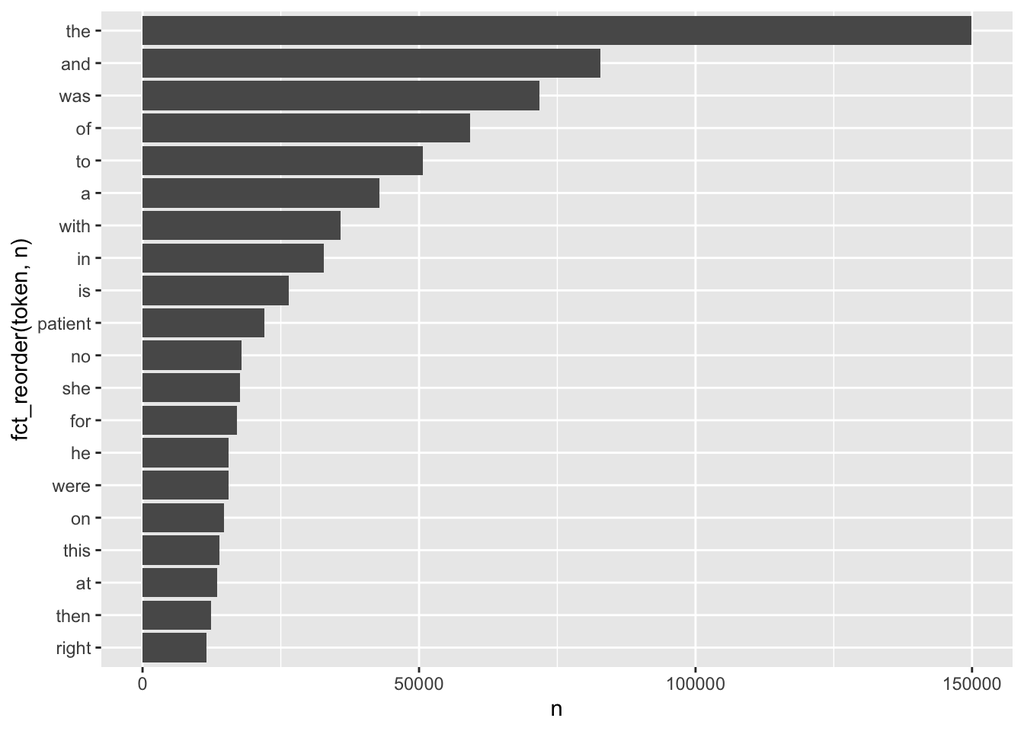

```r
library(forcats)

mt_samples %>%
  unnest_tokens(token, transcription) %>%
  count(token, sort = TRUE) %>%
  top_n(20, n) %>%
  ggplot(aes(x = n, y = fct_reorder(token, n)))+
  geom_col()
```

We can see that, among the top 20 words in “transcription”, there aren’t many words that will raise our interests.

## Question 3

- Redo visualization but remove stopwords before
- Bonus points if you remove numbers as well

What do we see know that we have removed stop words? Does it give us a better idea of what the text is about?

```r
library(stringr)
stop_words
```

```
## # A tibble: 1,149 x 2
##    word        lexicon
##    <chr>       <chr>
##  1 a           SMART
##  2 a's         SMART
##  3 able        SMART
##  4 about       SMART
##  5 above       SMART
##  6 according   SMART
##  7 accordingly SMART
##  8 across      SMART
##  9 actually    SMART
## 10 after       SMART
## # … with 1,139 more rows
```

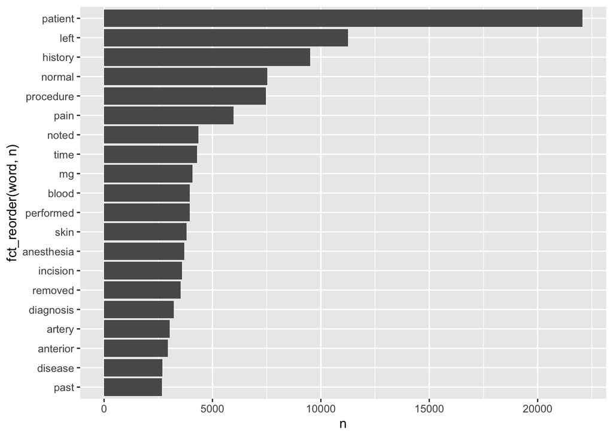

```r
nums=as.character(seq(0,100))

mt_samples %>%
  unnest_tokens(word, transcription) %>%
  anti_join(stop_words)%>%
  filter(!(word %in% nums)) %>%
  count(word, sort = TRUE) %>%
  top_n(20, n) %>%
  ggplot(aes(x = n, y = fct_reorder(word, n)))+
  geom_col()
```

```r
#trimws() remove spaces before and after a word
#str_squish() remove extra spaces between 2 words that suppose to have only #one space between.
```

After removing “stop_words” and “numbers”, we can see that, words start to seems interesting now.

# Question 4

repeat question 2, but this time tokenize into bi-grams. how does the result change if you look at tri-grams?

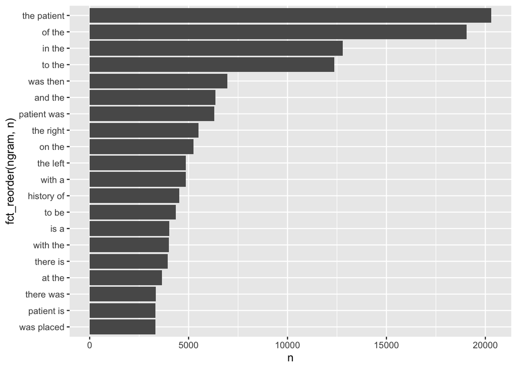

```r
mt_samples %>%
  unnest_ngrams(ngram, transcription, n = 2) %>%
  count(ngram, sort = TRUE) %>%
  top_n(20, n) %>%
  ggplot(aes(x = n, y = fct_reorder(ngram, n)))+
  geom_col()
```

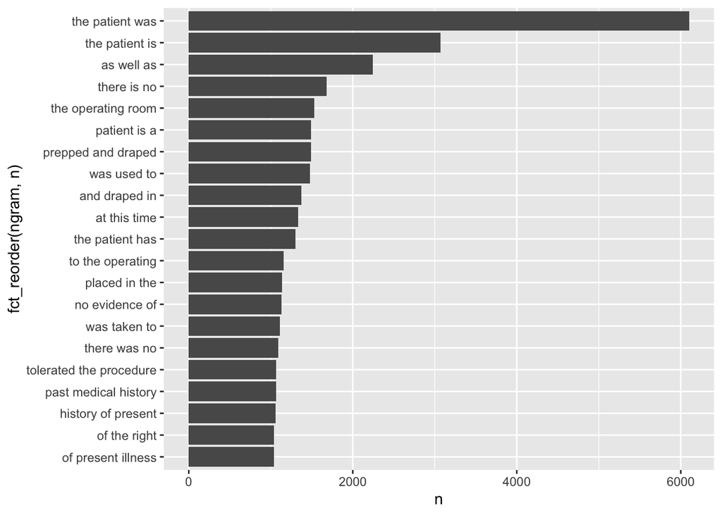

```r
mt_samples %>%
  unnest_ngrams(ngram, transcription, n = 3) %>%
  count(ngram, sort = TRUE) %>%
  top_n(20, n) %>%
  ggplot(aes(x = n, y = fct_reorder(ngram, n)))+
  geom_col()
```

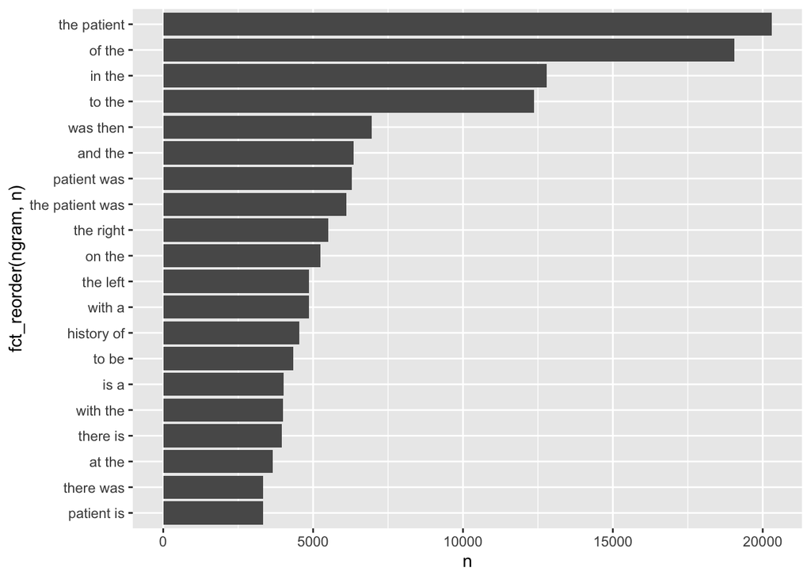

```r
#combine n=2 and n=3
mt_samples %>%
  unnest_ngrams(ngram, transcription, n = 3, n_min = 2) %>%
  count(ngram, sort = TRUE) %>%
  top_n(20, n) %>%
  ggplot(aes(x = n, y = fct_reorder(ngram, n)))+
  geom_col()
```

We can see that when n=3, we have a more interesting combination of words in “transcription”. For example: “the operating room”.

# Question 5

Using the results you got from questions 4. Pick a word and count the words that appears after and before it.

```r
library(tidyr)

mt_bigrams <- mt_samples %>%
  unnest_ngrams(ngram, transcription, n = 2) %>%
  separate(ngram, into = c("word1", "word2"), sep = " ") %>%
  select(word1, word2)

mt_bigrams %>%
  filter(word1 == "blood") %>%
  count(word2, sort = TRUE)
```

```
## # A tibble: 161 x 2
##    word2        n
##    <chr>    <int>
##  1 pressure  1265
##  2 loss       965
##  3 cell       130
##  4 in         114
##  5 cells      112
##  6 sugar       91
##  7 and         84
##  8 sugars      79
##  9 was         65
## 10 cultures    53
## # … with 151 more rows
```

```r
mt_bigrams %>%
  filter(word2 == "blood") %>%
  count(word1, sort = TRUE)
```

```
## # A tibble: 439 x 2
##    word1         n
##    <chr>     <int>
##  1 estimated   754
##  2 white       180
##  3 signs       170
##  4 and         154
##  5 of          149
##  6 red         123
##  7 her         116
##  8 his          99
##  9 the          96
## 10 no           72
## # … with 429 more rows
```

```r
#remove stopwords
mt_bigrams %>%
  anti_join(
    stop_words %>%
      select(word), by =c("word1" = "word")
    ) %>%
  anti_join(
    stop_words %>%
      select(word), by =c("word2" = "word")
    ) %>%
  count(word1, word2, sort=TRUE)
```

```
## # A tibble: 128,013 x 3
##    word1         word2           n
##    <chr>         <chr>       <int>
##  1 0             vicryl       1802
##  2 blood         pressure     1265
##  3 medical       history      1223
##  4 diagnoses     1            1192
##  5 preoperative  diagnosis    1176
##  6 physical      examination  1156
##  7 4             0            1123
##  8 vital         signs        1117
##  9 past          medical      1113
## 10 postoperative diagnosis    1092
## # … with 128,003 more rows
```

## We can see that bi-grams of “blood” appears far more interesting than the one without removing the stop words.

# Question 6

Which words are most used in each of the specialties. you can use `group_by()` and `top_n()` from `dplyr` to have the calculations be done within each specialty. Remember to remove stopwords. How about the most 5 used words?

```r
mt_samples %>%
  unnest_tokens(token, transcription) %>%
  anti_join(tidytext::stop_words, by = c("token" = "word")) %>%
  group_by(medical_specialty) %>%
  count(token) %>%
  top_n(1, n)
```

```
## # A tibble: 41 x 3
## # Groups:   medical_specialty [40]
##    medical_specialty          token       n
##    <chr>                      <chr>   <int>
##  1 Allergy / Immunology       history    38
##  2 Autopsy                    left       83
##  3 Bariatrics                 patient    62
##  4 Cardiovascular / Pulmonary left     1550
##  5 Chiropractic               pain      187
##  6 Consult - History and Phy. patient  3046
##  7 Cosmetic / Plastic Surgery patient   116
##  8 Dentistry                  patient   195
##  9 Dermatology                1         102
## 10 Diets and Nutritions       patient    43
## # … with 31 more rows
```

```r
mt_samples %>%
  unnest_tokens(token, transcription) %>%
  anti_join(tidytext::stop_words, by = c("token" = "word")) %>%
  group_by(medical_specialty) %>%
  count(token) %>%
  top_n(5, n)
```

```
## # A tibble: 209 x 3
## # Groups:   medical_specialty [40]
##    medical_specialty    token         n
##    <chr>                <chr>     <int>
##  1 Allergy / Immunology allergies    21
##  2 Allergy / Immunology history      38
##  3 Allergy / Immunology nasal        13
##  4 Allergy / Immunology noted        23
##  5 Allergy / Immunology past         13
##  6 Allergy / Immunology patient      22
##  7 Autopsy              1            66
##  8 Autopsy              anterior     47
##  9 Autopsy              inch         59
## 10 Autopsy              left         83
## # … with 199 more rows
```

We can see that “history” is often mentioned in medicial specialty of Allergy and Immunology.

# Question 7 - extra

Find your own insight in the data:

Ideas:

- Interesting ngrams
- See if certain words are used more in some specialties then others

```r
mt_samples %>%
  unnest_tokens(word, transcription) %>%
  count(word, medical_specialty) %>%
  bind_tf_idf(word, medical_specialty, n) %>%
  arrange(desc(tf_idf))
```

```
## # A tibble: 164,715 x 6
##    word         medical_specialty            n      tf   idf  tf_idf
##    <chr>        <chr>                    <int>   <dbl> <dbl>   <dbl>
##  1 carbohydrate Diets and Nutritions        37 0.00904 2.30  0.0208
##  2 reactivity   Lab Medicine - Pathology     7 0.00360 3.00  0.0108
##  3 calories     Diets and Nutritions        24 0.00586 1.61  0.00943
##  4 tumor        Lab Medicine - Pathology    35 0.0180  0.470 0.00847
##  5 meal         Diets and Nutritions        26 0.00635 1.29  0.00820
##  6 tooth        Dentistry                  108 0.00763 1.05  0.00801
##  7 linguistic   Speech - Language           13 0.00343 2.30  0.00789
##  8 lymph        Lab Medicine - Pathology    30 0.0154  0.511 0.00789
##  9 designated   Lab Medicine - Pathology     5 0.00257 3.00  0.00771
## 10 lobe         Lab Medicine - Pathology    29 0.0149  0.511 0.00762
## # … with 164,705 more rows
```